# Domaća zadaća 4

Ivana Tus

2022-11-12

U ovoj zadaći bilo je potrebno provesti i interpretirati različite statističke testove nad podacima iz datoteke rec.csv. Za početak učitamo csv datoteku kao programski okvir kako bismo mogli manipulirati podacima. U ovom dijelu pokazujemo različite grafičke prikaze podataka.

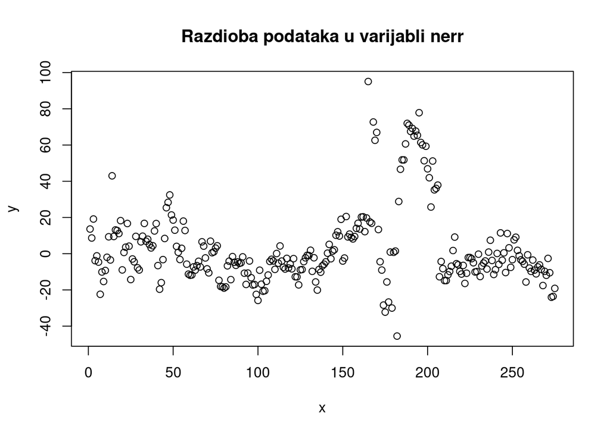

```r
#učitavanje podataka u programski okvir
dz4_data <- read.csv("rec.csv", header = TRUE)

#prikaz prave razdiobe podataka u varijablama nerr i eerr
plot(dz4_data$nerr, xlab = 'x', ylab ='y', main = 'Razdioba podataka u varijabli nerr')
```

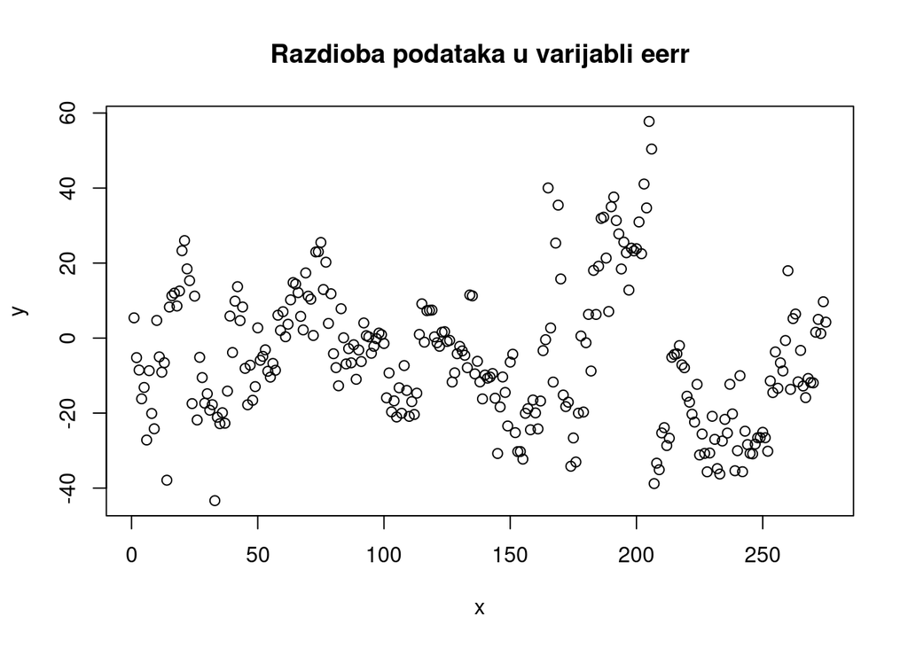

```r
plot(dz4_data$eerr, xlab = 'x', ylab ='y', main = 'Razdioba podataka u varijabli eerr')
```

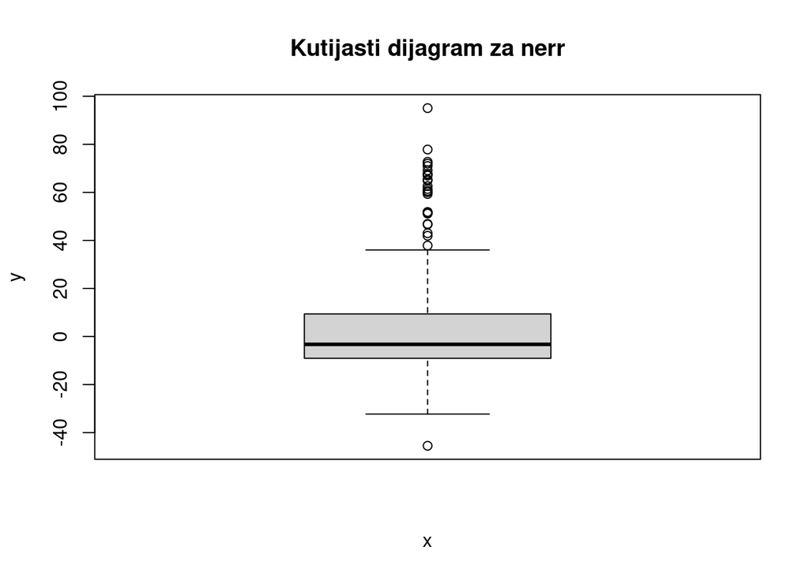

```r
#prikaz kvantila pomoću kutijastog dijagrama
boxplot(dz4_data$nerr, main='Kutijasti dijagram za nerr', xlab='x', ylab='y')
```

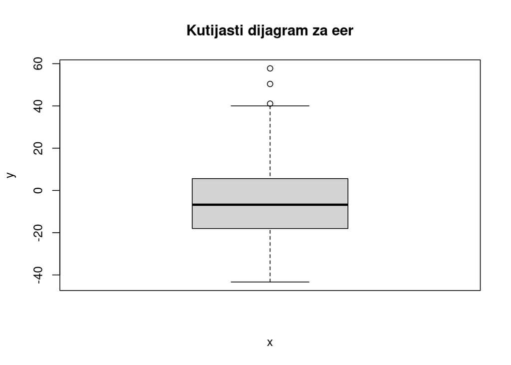

```r
boxplot(dz4_data$eerr, main='Kutijasti dijagram za eer', xlab='x', ylab='y')
```

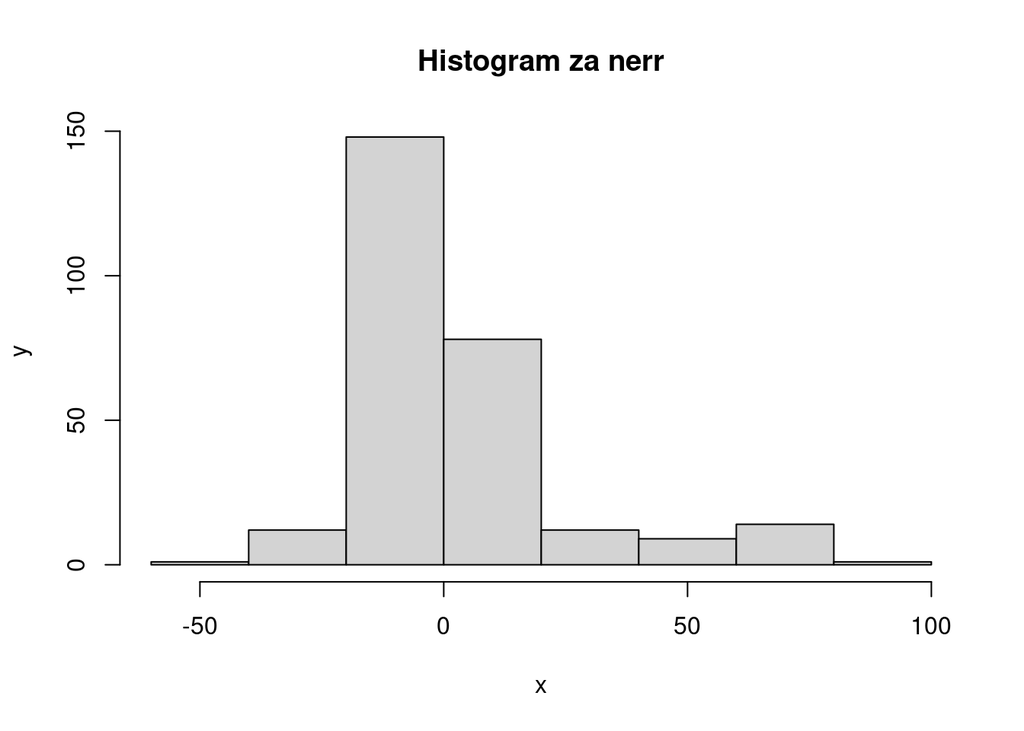

```r
#histogram razdiobe podataka
hist(dz4_data$nerr, xlab = 'x', ylab = 'y', main = 'Histogram za nerr')
```

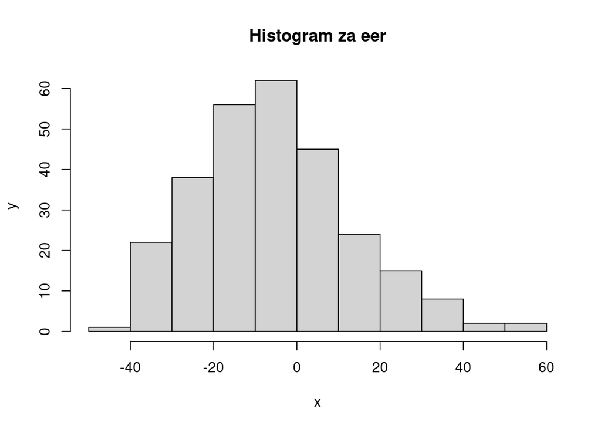

```r
hist(dz4_data$eerr, xlab = 'x', ylab = 'y', main = 'Histogram za eer')
```

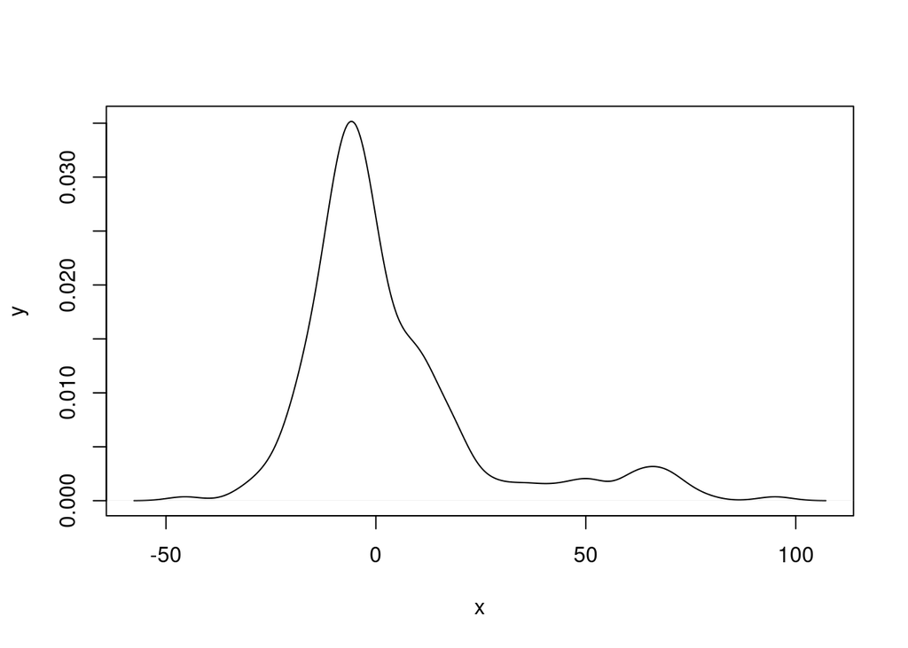

```r
#prikaz eksperimentalne funkcije gustoće vjerojatnosti
plot(density(dz4_data$nerr), main = '', xlab = 'x', ylab = 'y')
```

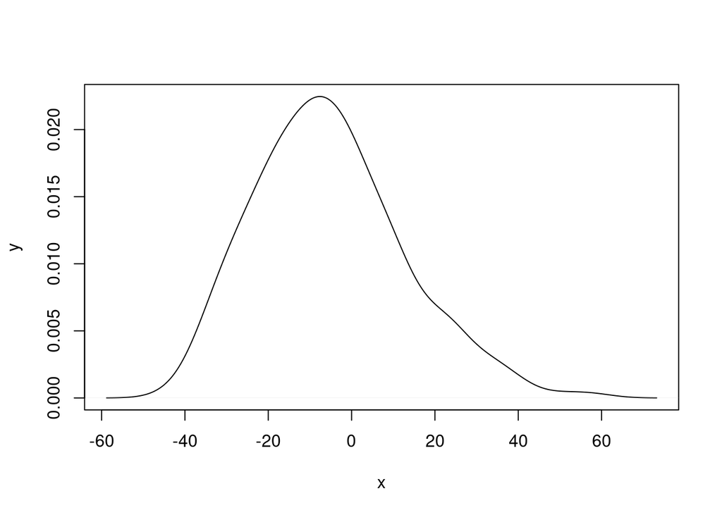

```r
plot(density(dz4_data$eerr), main = '', xlab = 'x', ylab = 'y')
```

Potom ispisujemo eksplorativnu statističku analizu (summary, hrv. sažetak) i standardnu devijaciju podataka.

```r
#standardna devijacija
print(sd(dz4_data$nerr))
```

```
## [1] 21.96838
```

```r
print(sd(dz4_data$eerr))
```

```
## [1] 17.90476
```

```r
#eksploraativna statističa analiza
print(summary(dz4_data$nerr))
```

```
##    Min. 1st Qu.  Median    Mean 3rd Qu.    Max.
## -45.499  -9.084  -3.274   3.285   9.392  95.061
```

```r
print(summary(dz4_data$eerr))
```

```
##    Min. 1st Qu.  Median    Mean 3rd Qu.    Max.
## -43.337 -18.026  -6.766  -5.361   5.589  57.756
```

Nakon toga krećemo s rarzličitim statističkim testovima. Prvi je na redu Shapiro-Wilk test koji provjerava je li se razdioba podataka došla iz normalne (Gaussove) razdiobe. Početna hipoteza (H0) ovog testa jest da je to istina.

```r
print(shapiro.test(dz4_data$nerr))
```

```
##
##  Shapiro-Wilk normality test
##
## data:  dz4_data$nerr
## W = 0.82874, p-value < 2.2e-16
```

```r
print(shapiro.test(dz4_data$eerr))
```

```
##
##  Shapiro-Wilk normality test
##
## data:  dz4_data$eerr
## W = 0.98016, p-value = 0.0007138
```

S obzirom da je p-value manji od 0.05 u oba slučaja, možemo odbaciti početnu hipotezu za obje varijable.

Sljedeći test je Kolmogorov-Smirnov test. Ovo je neparametarski test koji provjerava prate li podaci zadanu (u ovom slučaju normalnu) razdiobu te je početna hipoteza (H0) da prate.

```r
print(ks.test(dz4_data$nerr, 'pnorm'))
```

```
##
##  Asymptotic one-sample Kolmogorov-Smirnov test
##
## data:  dz4_data$nerr
## D = 0.53627, p-value < 2.2e-16
## alternative hypothesis: two-sided
```

```r
print(ks.test(dz4_data$eerr, 'pnorm'))
```

```
##
##  Asymptotic one-sample Kolmogorov-Smirnov test
##
## data:  dz4_data$eerr
## D = 0.59755, p-value < 2.2e-16
## alternative hypothesis: two-sided
```

U oba slučaja je p-value manja od 0.05, stoga se početna hipoteza može odbaciti za oba slučaja.

T test kao početnu hipotezu (H0) uzima da je razlika između dvaju uzoraka jednaka 0.

```r
print(t.test(dz4_data$nerr, dz4_data$eerr))
```

```
##
##  Welch Two Sample t-test
##
## data:  dz4_data$nerr and dz4_data$eerr
## t = 5.0592, df = 526.57, p-value = 5.826e-07
## alternative hypothesis: true difference in means is not equal to 0
## 95 percent confidence interval:
##   5.28885 12.00345
## sample estimates:
## mean of x mean of y
##  3.285349 -5.360801
```

S obzirom da je p-value manji od 0.05 te su izračunate srednje vrijednosti dviju varijabla različite, možemo odbaciti počtnu hipotezu.

Var test kao početnu hipotezu (H0) uzima pretpostavku da je omjer varijanci dvaju uzoraka 1.

```r
print(var.test(dz4_data$nerr, dz4_data$eerr))
```

```
##
##  F test to compare two variances
##
## data:  dz4_data$nerr and dz4_data$eerr
## F = 1.5054, num df = 274, denom df = 274, p-value = 0.0007491
## alternative hypothesis: true ratio of variances is not equal to 1
## 95 percent confidence interval:
##  1.187405 1.908619
## sample estimates:
## ratio of variances
##           1.505425
```

Vidimo da je p-value manji od 0.05 te da je pravi omjer varijanci 1.505425, stoga odbacujemo početnu hipotezu.